# full_analysis_study2

Rose M. Schneider

4/8/2021

# Study 2

## Participants

### Overall age demographics

```r
study2_data %>%
  distinct(subid, age)%>%
  summarise_at('age',
               list(~mean(., na.rm=T),
                    ~sd(., na.rm=T),
                    ~median(., na.rm=T),
                    ~min(., na.rm=T),
                    ~max(., na.rm=T),
                    ~sum(!is.na(.))))%>%
  dplyr::rename("n" = "sum")%>%
  dplyr::select(n, mean, sd, median, min, max)%>%
  knitr::kable()
```

| n | mean | sd | median | min | max |
| --- | --- | --- | --- | --- | --- |
| 63 | 10.12841 | 2.278573 | 10.28337 | 5.631759 | 14.26694 |

### Age bin and sex counts

```r
study2_data %>%
  distinct(subid, sex)%>%
  group_by(sex)%>%
  summarise(n = n())%>%
  mutate(total.site.n = sum(n))%>%
  knitr::kable()
```

| sex | n | total.site.n |
| --- | --- | --- |
| f | 30 | 63 |
| m | 33 | 63 |

## Ratings for moral, conventional, conventional-Iran, and religious items

### Descriptives

```r
study2_data %>%
  filter(q_kind == 0)%>%
  group_by(task)%>%
  summarise_at('answer',
               list(~mean(., na.rm=T),
                    ~sd(., na.rm=T),
                    ~median(., na.rm=T),
                    ~min(., na.rm=T),
                    ~max(., na.rm=T),
                    ~sum(!is.na(.))))%>%
  dplyr::rename("n" = "sum")%>%
  dplyr::select(task, n, mean, sd, median, min, max)%>%
  knitr::kable()
```

| task | n | mean | sd | median | min | max |
| --- | --- | --- | --- | --- | --- | --- |
| conv | 251 | 1.517928 | 0.7447666 | 1 | 1 | 4 |
| conv.iran | 252 | 1.904762 | 0.9608145 | 2 | 1 | 6 |
| moral | 189 | 1.460317 | 0.6480428 | 1 | 1 | 3 |
| religious | 252 | 1.519841 | 0.8766579 | 1 | 1 | 6 |

### Visualization of mean rating (all items collapsed) by site

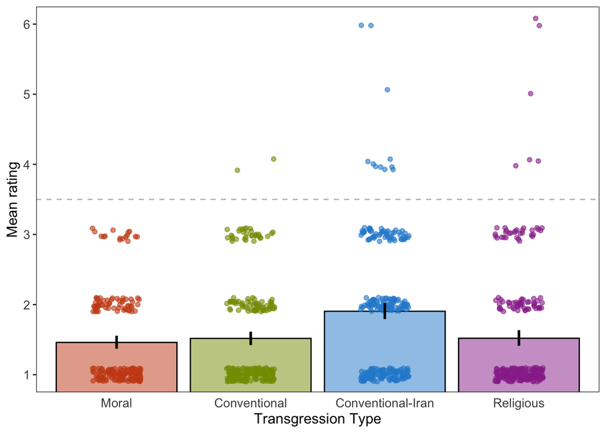

```r
study2_data %>%
  filter(q_kind == 0)%>%
  mutate(task = factor(task, levels = c("moral", "conv", "conv.iran", "religious"),
                       labels = c("Moral", "Conventional", "Conventional-Iran", "Religious")))%>%
  ggplot(aes(x = task, y = answer, fill = task, color = task)) +
  stat_summary(fun = mean, position = position_dodge(width = .9),
               geom="bar", alpha = .5, colour = "black") +
  geom_point(position=position_jitter(width = .18, height = .1),
             size=1.5,
             alpha = .6,
             show.legend=FALSE,
             inherit.aes = TRUE) +
  geom_hline(yintercept = 3.5, color = "grey", linetype = "dashed") +
  coord_cartesian(ylim = c(1, 6)) +
  stat_summary(fun.data = "mean_cl_boot", geom="linerange",
               position = position_dodge(width=0.9), size = 1, color = "black") +
  theme(legend.position = "none",
        # axis.text.x = element_blank(),
        axis.ticks.x = element_blank(),
        legend.key.size = unit(.5, 'cm'),
        legend.text = element_text(size = 10),
        legend.title = element_text(size = 11),
        legend.margin=margin(t = 0, unit='cm')) +
  langcog::scale_color_solarized() +
  langcog::scale_fill_solarized() +
  labs(y = "Mean rating",
       x = "Transgression Type") +
  scale_y_continuous(breaks = seq(1,6, 1))
```

```r
ggsave("study2_ratings.png", height = 3, width = 6)
```

### Visualization of ratings by age by task

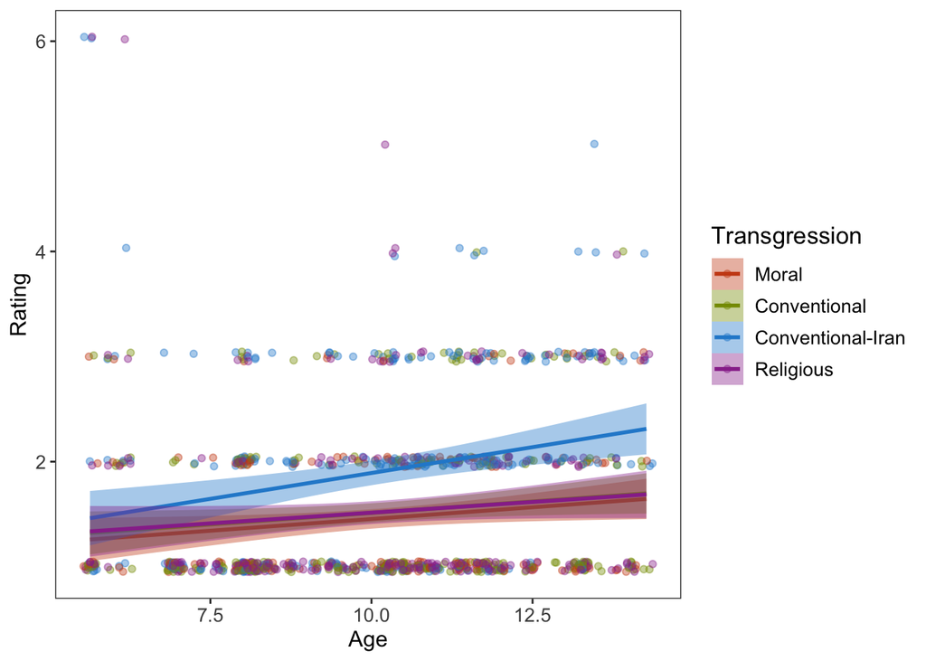

```r
study2_data %>%
  filter(q_kind == 0)%>%
  dplyr::rename("Transgression" = "task")%>%
  mutate(Transgression = factor(Transgression, levels = c("moral", "conv", "conv.iran", "religious"),
                       labels = c("Moral", "Conventional", "Conventional-Iran", "Religious")))%>%
  ggplot(aes(x = age, y= answer, color = Transgression, fill = Transgression)) +
  geom_point(position = position_jitter(width = .1, height = .05),
             alpha = .4) +
  geom_smooth(method ="lm") +
  langcog::scale_color_solarized() +
  langcog::scale_fill_solarized() +
  labs(x = "Age",
       y = "Rating")
```

### Visualization of mean rating (by item) by site

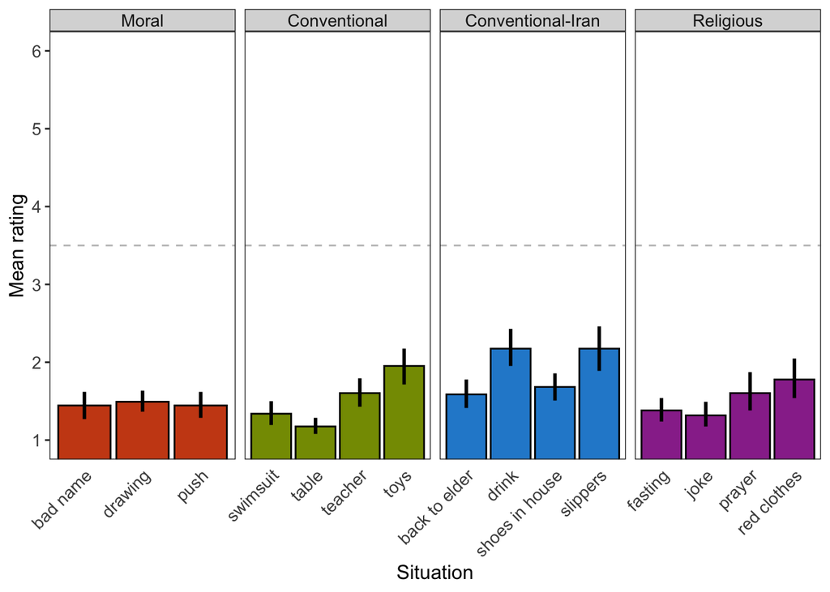

```r
study2_data %>%
  filter(q_kind == 0)%>%
  mutate(task = factor(task, levels = c("moral", "conv", "conv.iran", "religious"),
                       labels = c("Moral", "Conventional", "Conventional-Iran", "Religious")))%>%
  ggplot(aes(x = item, y = answer, fill =task)) +
  stat_summary(fun = mean, position = position_dodge(width = .9),
               geom="bar", colour = "black") +
  geom_hline(yintercept = 3.5, color = "grey", linetype = "dashed") +
  coord_cartesian(ylim = c(1, 6)) +
  facet_grid(~task, scale = "free_x") +
  stat_summary(fun.data = "mean_cl_boot", geom="linerange",
               position = position_dodge(width=0.9), size = 1, color = "black") +
  theme(legend.position = "none",
        axis.text.x = element_text(hjust = 1, angle = 45),
        axis.ticks.x = element_blank(),
        legend.key.size = unit(.5, 'cm'),
        legend.text = element_text(size = 10),
        legend.title = element_text(size = 11),
        legend.margin=margin(t = 0, unit='cm')) +
  langcog::scale_color_solarized() +
  langcog::scale_fill_solarized() +
  labs(y = "Mean rating",
       x = "Situation") +
  scale_y_continuous(breaks = seq(1,6, 1))
```

### Analyses of differences in rating between moral and conventional transgressions: Within-country

Pre-registered mixed-effects model: Rating ~ Transgression type (moral; conventional; conv.iran, religious)*Age + (Transgression type|Subject) + (age|item).

We will iteratively remove item slopes, then subject slopes, then will remove item effects altogether if necessary.

### Model: Answer ~ Task + Age + (1|subid)

**Note** Item model will not converge, so this is our only model

```r
#summary of item model
knitr::kable(summary(iran.rating.base)$coef)
```

|  | Estimate | Std. Error | df | t value | Pr(>\|t\|) |
| --- | --- | --- | --- | --- | --- |
| (Intercept) | 1.4603175 | 0.0691986 | 219.07672 | 21.1032771 | 0.0000000 |
| taskconv | 0.0587516 | 0.0715889 | 878.05376 | 0.8206802 | 0.4120512 |
| taskconv.iran | 0.4444444 | 0.0715246 | 878.00161 | 6.2138647 | 0.0000000 |
| taskreligious | 0.0595238 | 0.0715246 | 878.00161 | 0.8322140 | 0.4055144 |
| age.c | 0.1302533 | 0.0494984 | 60.96852 | 2.6314613 | 0.0107528 |

```r
study2_data %>%
  filter(q_kind != 0)%>%
  group_by(task, q_kind_label)%>%
  summarise_at('answer',
               list(~mean(., na.rm=T),
                    ~sd(., na.rm=T),
                    ~sum(!is.na(.))))%>%
  dplyr::rename("n" = "sum")%>%
  dplyr::select(task, q_kind_label, n, mean, sd)%>%
  knitr::kable()
```

| task | q_kind_label | n | mean | sd |
| --- | --- | --- | --- | --- |
| conv | Everyone else | 249 | 0.2570281 | 0.4378752 |
| conv | Faraway country | 251 | 0.2071713 | 0.4060891 |
| conv | Foreigner | 251 | 0.1633466 | 0.3704202 |
| conv | Haram | 251 | 0.4223108 | 0.4949144 |
| conv | Illegal | 251 | 0.4940239 | 0.5009632 |
| conv | Non-Muslim | 250 | 0.1400000 | 0.3476831 |
| conv | Rule at school | 251 | 0.3306773 | 0.4713970 |
| conv | Zesht | 251 | 0.9561753 | 0.2051139 |
| conv.iran | Everyone else | 252 | 0.3293651 | 0.4709180 |
| conv.iran | Faraway country | 252 | 0.3134921 | 0.4648357 |
| conv.iran | Foreigner | 252 | 0.3412698 | 0.4750793 |
| conv.iran | Haram | 250 | 0.3560000 | 0.4797757 |
| conv.iran | Illegal | 252 | 0.2896825 | 0.4545177 |
| conv.iran | Non-Muslim | 252 | 0.2857143 | 0.4526530 |
| conv.iran | Rule at school | 252 | 0.4087302 | 0.4925776 |
| conv.iran | Zesht | 252 | 0.9087302 | 0.3020567 |
| moral | Everyone else | 189 | 0.1322751 | 0.3396895 |
| moral | Faraway country | 189 | 0.1375661 | 0.3453589 |
| moral | Foreigner | 189 | 0.1216931 | 0.3277994 |
| moral | Haram | 189 | 0.4708995 | 0.5004782 |
| moral | Illegal | 188 | 0.5000000 | 0.5013351 |
| moral | Non-Muslim | 189 | 0.0952381 | 0.2943232 |
| moral | Rule at school | 189 | 0.2116402 | 0.4095560 |
| moral | Zesht | 252 | 0.9920635 | 0.0889094 |
| religious | Everyone else | 251 | 0.1434263 | 0.3512074 |
| religious | Faraway country | 252 | 0.3412698 | 0.4750793 |
| religious | Foreigner | 252 | 0.3452381 | 0.4763920 |
| religious | Haram | 251 | 0.7330677 | 0.4432405 |
| religious | Illegal | 252 | 0.6150794 | 0.4875449 |
| religious | Non-Muslim | 252 | 0.3809524 | 0.4865873 |
| religious | Rule at school | 250 | 0.3440000 | 0.4759940 |
| religious | Zesht | 189 | 0.8994709 | 0.3015029 |

### Visualization of acceptability by task

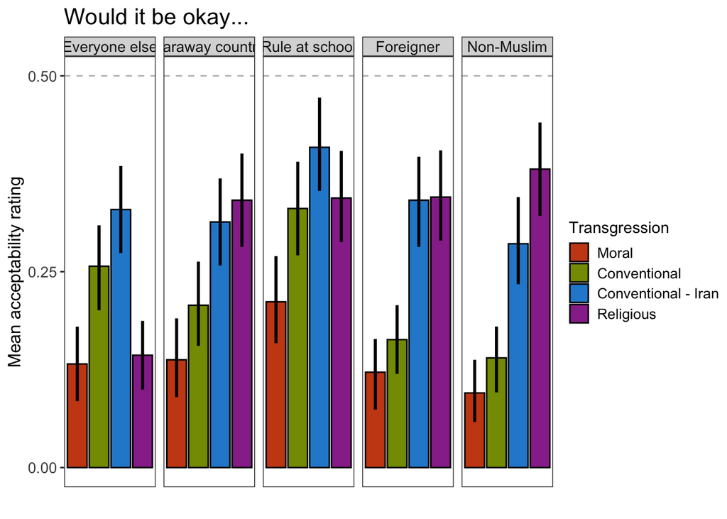

```r
study2_data %>%
  filter(q_kind != 0,
         q_kind_label != "Haram",
           q_kind_label != "Illegal",
           q_kind_label != "Zesht")%>%
  mutate(task = factor(task, levels = c("moral", "conv", "conv.iran", "religious"),
                       labels = c("Moral", "Conventional", "Conventional - Iran", "Religious")),
         q_kind_label = factor(q_kind_label, levels = c("Everyone else", "Faraway country", "Rule at school", "Foreigner",
                                                        "Non-Muslim")))%>%
  ggplot(aes(x = task, y = answer, fill = task, color = task)) +
  stat_summary(fun = mean, position = position_dodge(width = .9),
               geom="bar", colour = "black") +
  geom_hline(yintercept = .5, color = "grey", linetype = "dashed") +
  stat_summary(fun.data = "mean_cl_boot", geom="linerange",
               position = position_dodge(width=0.9), size = 1, color = "black") +
  facet_grid(~q_kind_label) +
  theme(legend.position = "right",
        axis.text.x = element_blank(),
        axis.ticks.x = element_blank(),
        legend.key.size = unit(.5, 'cm'),
        legend.text = element_text(size = 10),
        legend.title = element_text(size = 11),
        legend.margin=margin(t = 0, unit='cm')) +
  langcog::scale_color_solarized() +
  langcog::scale_fill_solarized() +
  labs(y = "Mean acceptability rating",
       x = "",
       fill = "Transgression") +
  ggtitle("Would it be okay...") +
  scale_y_continuous(breaks = seq(0, .50, .25))
```

```r
ggsave("study2_acceptability_ratings_main.png", height = 3, width = 8.5)
```

### Visualization of illegal, haram, zesht

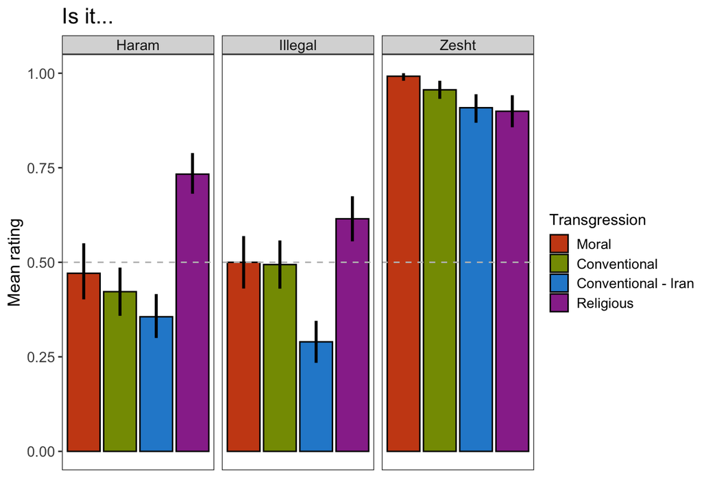

```r
study2_data %>%
  filter(q_kind != 0,
         q_kind_label == "Haram" |
           q_kind_label == "Illegal" |
           q_kind_label == "Zesht")%>%
  mutate(task = factor(task, levels = c("moral", "conv", "conv.iran", "religious"),
                       labels = c("Moral", "Conventional", "Conventional - Iran", "Religious")))%>%
  ggplot(aes(x = task, y = answer, fill = task, color = task)) +
  stat_summary(fun = mean, position = position_dodge(width = .9),
               geom="bar", colour = "black") +
  geom_hline(yintercept = .5, color = "grey", linetype = "dashed") +
  stat_summary(fun.data = "mean_cl_boot", geom="linerange",
               position = position_dodge(width=0.9), size = 1, color = "black") +
  facet_grid(~q_kind_label) +
  theme(legend.position = "right",
        axis.text.x = element_blank(),
        axis.ticks.x = element_blank(),
        legend.key.size = unit(.5, 'cm'),
        legend.text = element_text(size = 10),
        legend.title = element_text(size = 11),
        legend.margin=margin(t = 0, unit='cm')) +
  langcog::scale_color_solarized() +
  langcog::scale_fill_solarized() +
  labs(y = "Mean rating",
       x = "",
       fill = "Transgression") +
  ggtitle("Is it...") +
ggsave("study2_acceptability_ratings_supp.png", height = 3, width = 8.5)
```

### Analysis of acceptability ratings by transgression type: Within-country:

Pre-registration: Response (yes/no) ~ Transgression type (moral; conventional; conventional-Iran; religious) *Age + (transgression type|subject) +(age|item). Once again we will begin with a maximal random effects structure, and iteratively remove coefficients until the model converges. We will begin first by removing the slope of the item effect, then of subject, and if necessary removing the item effect altogether.

#### If everyone else were doing it: Answer ~ Task + Age + (1|subid)

**Note** Model will not converge with item random effect.

1. Interaction between task and age not significant, so dropped from the model ($\chi^{2}$ = 6.14, *p* = 0.10)
2. Significant difference in acceptability between moral and conventional ($\beta$ = 1.26, *p* < .001)
3. Significant difference in acceptability between moral and conventional-Iran ($\beta$ = 1.84, *p* < .001)
4. No significant difference in acceptability between moral and religious ($\beta$ = .13, *p* = .70)
5. Significant effect of age ($\beta$ = 0.92, *p* < .001)

```r
##summary of main effects
knitr::kable(summary(everyone.base)$coef)
```

|  | Estimate | Std. Error | z value | Pr(>\|z\|) |
| --- | --- | --- | --- | --- |
| (Intercept) | -3.0283682 | 0.3830448 | -7.9060411 | 0.0000000 |
| taskconv | 1.2625036 | 0.3248764 | 3.8861048 | 0.0001019 |
| taskconv.iran | 1.8417229 | 0.3252193 | 5.6630181 | 0.0000000 |
| taskreligious | 0.1323504 | 0.3403666 | 0.3888468 | 0.6973895 |
| age.c | 0.9244460 | 0.2649814 | 3.4887203 | 0.0004853 |

#### Far away: Answer ~ Task + Age + (1|subid)

**Note** Model will not converge with item random effect.

1. Interaction between task and age not significant, so dropped from the model ($\chi^{2}$ = 4.00, *p* = 0.26)
2. Significant difference in acceptability between moral and conventional ($\beta$ = .69, *p* = .03)
3. Significant difference in acceptability between moral and conventional-Iran ($\beta$ = 1.51, *p* < .001)
4. Significant difference in acceptability between moral and religious ($\beta$ = 1.70, *p* < .001)
5. Significant effect of age ($\beta$ = 0.70, *p* = .002)

```r
##summary of main effects
knitr::kable(summary(faraway.base)$coef)
```

|  | Estimate | Std. Error | z value | Pr(>\|z\|) |
| --- | --- | --- | --- | --- |
| (Intercept) | -2.6612094 | 0.3333518 | -7.983186 | 0.0000000 |
| taskconv | 0.6910018 | 0.3118008 | 2.216164 | 0.0266803 |
| taskconv.iran | 1.5139795 | 0.3054579 | 4.956426 | 0.0000007 |
| taskreligious | 1.7028893 | 0.3055556 | 5.573092 | 0.0000000 |
| age.c | 0.6963177 | 0.2215266 | 3.143270 | 0.0016707 |

#### Rule at school: Answer ~ Task + Age + (1|subid)

**Note** Model will not converge with item random effect.

```r
##summary of main effects
knitr::kable(summary(rule.base)$coef)
```

|  | Estimate | Std. Error | z value | Pr(>\|z\|) |
| --- | --- | --- | --- | --- |
| (Intercept) | -2.0427022 | 0.3029894 | -6.741828 | 0.0000000 |
| taskconv | 0.9110185 | 0.2688174 | 3.388986 | 0.0007015 |
| taskconv.iran | 1.4486364 | 0.2696014 | 5.373253 | 0.0000001 |
| taskreligious | 0.9999589 | 0.2688213 | 3.719791 | 0.0001994 |
| age.c | 0.7345515 | 0.2251623 | 3.262320 | 0.0011050 |

#### Foreigner: Answer ~ Task + Age +Task:Age + (1|subid)

**Note** Model will not converge with item random effect.

```r
##summary of main effects
knitr::kable(summary(foreigner)$coef)
```

|  | Estimate | Std. Error | z value | Pr(>\|z\|) |
| --- | --- | --- | --- | --- |
| (Intercept) | -3.0498632 | 0.3853213 | -7.9151170 | 0.0000000 |
| taskconv | 0.5387188 | 0.3524707 | 1.5284073 | 0.1264114 |
| taskconv.iran | 2.0114598 | 0.3432396 | 5.8602205 | 0.0000000 |
| taskreligious | 1.8946883 | 0.3504999 | 5.4056744 | 0.0000001 |
| age.c | 0.6743616 | 0.3558094 | 1.8952887 | 0.0580542 |
| taskconv:age.c | -0.1739956 | 0.3278825 | -0.5306644 | 0.5956514 |
| taskconv.iran:age.c | 0.0338030 | 0.3189473 | 0.1059831 | 0.9155958 |
| taskreligious:age.c | 0.7808776 | 0.3407689 | 2.2915169 | 0.0219335 |

#### Non-Muslim: Answer ~ Task + Age + Task:Age + (1|subid)

**Note** Model will not converge with item random effect.

1. Significant interaction between task and age ($\chi^{2}$ = 15.37, *p* = .002)
2. No significant difference in acceptability between moral and conventional ($\beta$ = .40, *p* =.30)
3. Significant difference in acceptability between moral and conventional-Iran ($\beta$ = 1.77, *p* < .001)
4. Significant difference in acceptability between moral and religious ($\beta$ = 2.38, *p* < .001)
5. No effect of age ($\beta$ = -0.08, *p* = .83)
6. Significant interaction between age and conventional items ($\beta$ = 0.85, *p* = .03)
7. Significant interaction between age and conventional-Iran items ($\beta$ = .77, *p* =.03)
8. Significant interaction between age and religious items ($\beta$ = 1.38, *p* < .001)

```r
##summary of main effects
knitr::kable(summary(muslim)$coef)
```

|  | Estimate | Std. Error | z value | Pr(>\|z\|) |
| --- | --- | --- | --- | --- |
| (Intercept) | -3.2468560 | 0.3927954 | -8.2660233 | 0.0000000 |
| taskconv | 0.3863519 | 0.3754123 | 1.0291403 | 0.3034137 |
| taskconv.iran | 1.7705884 | 0.3468150 | 5.1052824 | 0.0000003 |
| taskreligious | 2.3718117 | 0.3559482 | 6.6633623 | 0.0000000 |
| age.c | -0.0784765 | 0.3743394 | -0.2096401 | 0.8339486 |
| taskconv:age.c | 0.8466164 | 0.3817339 | 2.2178178 | 0.0265673 |
| taskconv.iran:age.c | 0.7749229 | 0.3442575 | 2.2509977 | 0.0243857 |
| taskreligious:age.c | 1.3763659 | 0.3597633 | 3.8257538 | 0.0001304 |

#### Haram: Answer ~ Task + Age + (1|subid)

**Note** Model will not converge with item random effect.

1. No significant interaction between task and age ($\chi^{2}$ = 5.59, *p* = .13)
2. No significant difference between moral and conventional ($\beta$ = -0.41, *p* =.14)
3. Significant difference between moral and conventional-Iran ($\beta$ = -1.01, *p* < .001)
4. Significant difference between moral and religious ($\beta$ = 2.02, *p* < .001)
5. Significant effect of age ($\beta$ = -1.31, *p* < .001)

```r
##summary of main effects
knitr::kable(summary(haram.base)$coef)
```

|  | Estimate | Std. Error | z value | Pr(>\|z\|) |
| --- | --- | --- | --- | --- |
| (Intercept) | -0.0323946 | 0.3282018 | -0.0987034 | 0.9213738 |
| taskconv | -0.4081547 | 0.2796334 | -1.4596063 | 0.1443983 |
| taskconv.iran | -1.0171270 | 0.2908259 | -3.4973739 | 0.0004699 |
| taskreligious | 2.0196392 | 0.2905923 | 6.9500771 | 0.0000000 |
| age.c | -1.3051763 | 0.2763683 | -4.7225980 | 0.0000023 |

#### Illegal: Answer ~ Task + Age + (1|subid)

**Note** Model will not converge with item random effect.

1. No significant interaction between task and age ($\chi^{2}$ = 1.37, *p* = .71)
2. No significant difference between moral and conventional ($\beta$ = -0.03, *p* =.90)
3. Significant difference between moral and conventional-Iran ($\beta$ = -1.50, *p* < .001)
4. Significant difference moral and religious ($\beta$ = 0.78, *p* = .002)
5. Significant effect of age ($\beta$ = -1.12, *p* < .001)

```r
##summary of main effects
knitr::kable(summary(illegal.base)$coef)
```

|  | Estimate | Std. Error | z value | Pr(>\|z\|) |
| --- | --- | --- | --- | --- |
| (Intercept) | 0.0751136 | 0.2918094 | 0.2574065 | 0.7968650 |
| taskconv | -0.0301134 | 0.2439432 | -0.1234444 | 0.9017552 |
| taskconv.iran | -1.5019044 | 0.2654652 | -5.6576324 | 0.0000000 |
| taskreligious | 0.7753516 | 0.2470899 | 3.1379335 | 0.0017014 |
| age.c | -1.1190982 | 0.2496486 | -4.4826944 | 0.0000074 |

#### Zesht: Answer ~ Task + Age + (1|subid)

**Note** Model will not converge with item random effect.

1. No significant interaction between task and age ($\chi^{2}$ = 1.37, *p* = .71)
2. Significant difference between moral and conventional ($\beta$ = -1.87, *p* =.02)
3. Significant difference between moral and conventional-Iran ($\beta$ = -2.85, *p* < .001)
4. Significant difference between moral and religious ($\beta$ = -2.93, *p* < .001)
5. Significant effect of age ($\beta$ = -0.54, *p* = .02)

```r
##summary of main effects
knitr::kable(summary(zesht.base)$coef)
```

|  | Estimate | Std. Error | z value | Pr(>\|z\|) |
| --- | --- | --- | --- | --- |
| (Intercept) | 5.8283049 | 0.7950663 | 7.330590 | 0.0000000 |
| taskconv | -1.8721151 | 0.7942695 | -2.357028 | 0.0184219 |
| taskconv.iran | -2.8522759 | 0.7661845 | -3.722701 | 0.0001971 |
| taskreligious | -2.9253547 | 0.7767773 | -3.766014 | 0.0001659 |
| age.c | -0.5400336 | 0.2388134 | -2.261321 | 0.0237394 |